# TME06 Bagging, Boosting

## Imports

```python
import numpy as np
from mltools import plot_data, plot_frontiere, make_grid, gen_arti
from sklearn.model_selection import train_test_split
from sklearn.ensemble import RandomForestClassifier
from sklearn.tree import DecisionTreeClassifier
import matplotlib.pyplot as plt
```

## Forêts aléatoires (Bagging)

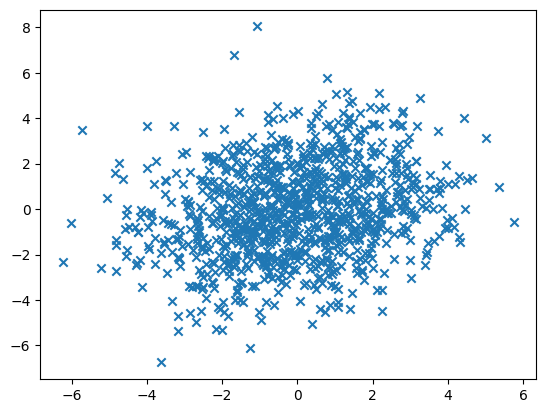

```python
# Nos données artificielles (2D)
np.random.seed(0)
data, y = gen_arti(centerx=1, centery=1, sigma=0.9, nbex=1000, data_type=0, epsilon=1.5)

plot_data(data)
```

```python
# Séparation en train/test (70% train, 30% test)
data_train, data_test, y_train, y_test = train_test_split(data, y, test_size=0.3, random_state=42)
```

Nous allons tester différents paramètres (n_estimators : nombre d'arbres, max_depth : profondeur des arbres, min_samples_split : nombre minimum d’échantillons pour diviser un nœud, min_samples_leaf : nombre minimum d’échantillons par feuille) et étudier l'évolution des frontières de décision, de l'erreur en apprentissage et de l'erreur en test.

```
Criterion: gini, Min Split: 2, Min Leaf: 1, Max Depth: None, N Estimators: 1, Train Acc: 89.29, Test Acc: 68.67
Criterion: gini, Min Split: 2, Min Leaf: 1, Max Depth: None, N Estimators: 5, Train Acc: 97.00, Test Acc: 76.00
Criterion: gini, Min Split: 2, Min Leaf: 1, Max Depth: None, N Estimators: 50, Train Acc: 100.00, Test Acc: 77.67
Criterion: gini, Min Split: 2, Min Leaf: 1, Max Depth: 1, N Estimators: 1, Train Acc: 68.57, Test Acc: 70.00
Criterion: gini, Min Split: 2, Min Leaf: 1, Max Depth: 1, N Estimators: 5, Train Acc: 78.00, Test Acc: 79.00
Criterion: gini, Min Split: 2, Min Leaf: 1, Max Depth: 1, N Estimators: 50, Train Acc: 77.29, Test Acc: 75.67
Criterion: gini, Min Split: 2, Min Leaf: 1, Max Depth: 5, N Estimators: 1, Train Acc: 79.43, Test Acc: 77.67
Criterion: gini, Min Split: 2, Min Leaf: 1, Max Depth: 5, N Estimators: 5, Train Acc: 81.43, Test Acc: 81.00
Criterion: gini, Min Split: 2, Min Leaf: 1, Max Depth: 5, N Estimators: 50, Train Acc: 82.00, Test Acc: 80.67
Criterion: gini, Min Split: 2, Min Leaf: 1, Max Depth: 50, N Estimators: 1, Train Acc: 89.29, Test Acc: 68.67
Criterion: gini, Min Split: 2, Min Leaf: 1, Max Depth: 50, N Estimators: 5, Train Acc: 97.00, Test Acc: 76.00
Criterion: gini, Min Split: 2, Min Leaf: 1, Max Depth: 50, N Estimators: 50, Train Acc: 100.00, Test Acc: 77.67
Criterion: gini, Min Split: 2, Min Leaf: 1, Max Depth: 100, N Estimators: 1, Train Acc: 89.29, Test Acc: 68.67
Criterion: gini, Min Split: 2, Min Leaf: 1, Max Depth: 100, N Estimators: 5, Train Acc: 97.00, Test Acc: 76.00
Criterion: gini, Min Split: 2, Min Leaf: 1, Max Depth: 100, N Estimators: 50, Train Acc: 100.00, Test Acc: 77.67
Criterion: gini, Min Split: 2, Min Leaf: 3, Max Depth: None, N Estimators: 1, Train Acc: 82.71, Test Acc: 72.00
Criterion: gini, Min Split: 2, Min Leaf: 3, Max Depth: None, N Estimators: 5, Train Acc: 88.71, Test Acc: 78.00
Criterion: gini, Min Split: 2, Min Leaf: 3, Max Depth: None, N Estimators: 50, Train Acc: 90.14, Test Acc: 80.67
Criterion: gini, Min Split: 2, Min Leaf: 3, Max Depth: 1, N Estimators: 1, Train Acc: 68.57, Test Acc: 70.00
Criterion: gini, Min Split: 2, Min Leaf: 3, Max Depth: 1, N Estimators: 5, Train Acc: 78.00, Test Acc: 79.00
Criterion: gini, Min Split: 2, Min Leaf: 3, Max Depth: 1, N Estimators: 50, Train Acc: 77.29, Test Acc: 75.67
Criterion: gini, Min Split: 2, Min Leaf: 3, Max Depth: 5, N Estimators: 1, Train Acc: 79.00, Test Acc: 77.33
Criterion: gini, Min Split: 2, Min Leaf: 3, Max Depth: 5, N Estimators: 5, Train Acc: 81.00, Test Acc: 81.00
Criterion: gini, Min Split: 2, Min Leaf: 3, Max Depth: 5, N Estimators: 50, Train Acc: 81.86, Test Acc: 80.00
Criterion: gini, Min Split: 2, Min Leaf: 3, Max Depth: 50, N Estimators: 1, Train Acc: 82.71, Test Acc: 72.00
Criterion: gini, Min Split: 2, Min Leaf: 3, Max Depth: 50, N Estimators: 5, Train Acc: 88.71, Test Acc: 78.00
Criterion: gini, Min Split: 2, Min Leaf: 3, Max Depth: 50, N Estimators: 50, Train Acc: 90.14, Test Acc: 80.67
Criterion: gini, Min Split: 2, Min Leaf: 3, Max Depth: 100, N Estimators: 1, Train Acc: 82.71, Test Acc: 72.00
Criterion: gini, Min Split: 2, Min Leaf: 3, Max Depth: 100, N Estimators: 5, Train Acc: 88.71, Test Acc: 78.00
Criterion: gini, Min Split: 2, Min Leaf: 3, Max Depth: 100, N Estimators: 50, Train Acc: 90.14, Test Acc: 80.67
Criterion: gini, Min Split: 2, Min Leaf: 5, Max Depth: None, N Estimators: 1, Train Acc: 81.14, Test Acc: 74.33
Criterion: gini, Min Split: 2, Min Leaf: 5, Max Depth: None, N Estimators: 5, Train Acc: 84.14, Test Acc: 78.67
Criterion: gini, Min Split: 2, Min Leaf: 5, Max Depth: None, N Estimators: 50, Train Acc: 85.29, Test Acc: 80.33
Criterion: gini, Min Split: 2, Min Leaf: 5, Max Depth: 1, N Estimators: 1, Train Acc: 68.57, Test Acc: 70.00
Criterion: gini, Min Split: 2, Min Leaf: 5, Max Depth: 1, N Estimators: 5, Train Acc: 78.00, Test Acc: 79.00
Criterion: gini, Min Split: 2, Min Leaf: 5, Max Depth: 1, N Estimators: 50, Train Acc: 77.29, Test Acc: 75.67
Criterion: gini, Min Split: 2, Min Leaf: 5, Max Depth: 5, N Estimators: 1, Train Acc: 79.00, Test Acc: 79.33
Criterion: gini, Min Split: 2, Min Leaf: 5, Max Depth: 5, N Estimators: 5, Train Acc: 80.57, Test Acc: 82.00
Criterion: gini, Min Split: 2, Min Leaf: 5, Max Depth: 5, N Estimators: 50, Train Acc: 81.29, Test Acc: 80.00
Criterion: gini, Min Split: 2, Min Leaf: 5, Max Depth: 50, N Estimators: 1, Train Acc: 81.14, Test Acc: 74.33
```

[output cut: 185 more lines]

```
Criterion: gini, Min Split: 10, Min Leaf: 10, Max Depth: None, N Estimators: 1, Train Acc: 77.86, Test Acc: 78.33
Criterion: gini, Min Split: 10, Min Leaf: 10, Max Depth: None, N Estimators: 5, Train Acc: 81.00, Test Acc: 81.33
Criterion: gini, Min Split: 10, Min Leaf: 10, Max Depth: None, N Estimators: 50, Train Acc: 82.14, Test Acc: 79.67
Criterion: gini, Min Split: 10, Min Leaf: 10, Max Depth: 1, N Estimators: 1, Train Acc: 68.57, Test Acc: 70.00
Criterion: gini, Min Split: 10, Min Leaf: 10, Max Depth: 1, N Estimators: 5, Train Acc: 78.00, Test Acc: 79.00
Criterion: gini, Min Split: 10, Min Leaf: 10, Max Depth: 1, N Estimators: 50, Train Acc: 77.29, Test Acc: 75.67
Criterion: gini, Min Split: 10, Min Leaf: 10, Max Depth: 5, N Estimators: 1, Train Acc: 78.29, Test Acc: 78.67
Criterion: gini, Min Split: 10, Min Leaf: 10, Max Depth: 5, N Estimators: 5, Train Acc: 79.86, Test Acc: 81.00
Criterion: gini, Min Split: 10, Min Leaf: 10, Max Depth: 5, N Estimators: 50, Train Acc: 80.86, Test Acc: 80.33
Criterion: gini, Min Split: 10, Min Leaf: 10, Max Depth: 50, N Estimators: 1, Train Acc: 77.86, Test Acc: 78.33
Criterion: gini, Min Split: 10, Min Leaf: 10, Max Depth: 50, N Estimators: 5, Train Acc: 81.00, Test Acc: 81.33
Criterion: gini, Min Split: 10, Min Leaf: 10, Max Depth: 50, N Estimators: 50, Train Acc: 82.14, Test Acc: 79.67
Criterion: gini, Min Split: 10, Min Leaf: 10, Max Depth: 100, N Estimators: 1, Train Acc: 77.86, Test Acc: 78.33
Criterion: gini, Min Split: 10, Min Leaf: 10, Max Depth: 100, N Estimators: 5, Train Acc: 81.00, Test Acc: 81.33
Criterion: gini, Min Split: 10, Min Leaf: 10, Max Depth: 100, N Estimators: 50, Train Acc: 82.14, Test Acc: 79.67
```

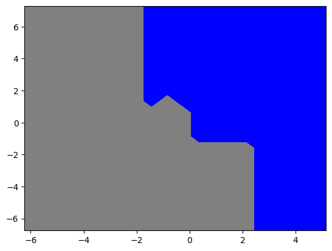

```python
n_estimators_list = [1, 5, 50]
max_depth_list = [None, 1, 5, 50, 100]
min_samples_split_list = [2, 3, 5, 10]
min_samples_leaf_list = [1, 3, 5, 10]

for min_samples_split in min_samples_split_list :
        for min_samples_leaf in min_samples_leaf_list :
            for max_depth in max_depth_list :
                for n_estimators in n_estimators_list :
                    classifier = RandomForestClassifier(n_estimators=n_estimators, max_depth=max_depth, min_samples_split=min_samples_split, min_samples_leaf=min_samples_leaf, random_state=42)
                    classifier.fit(data_train, y_train.ravel())  # On utilise .ravel() car y_train est un tableau 2D
                    y_pred_train = classifier.predict(data_train)
                    y_pred_test = classifier.predict(data_test)

                    train_acc = (y_pred_train == y_train.ravel()).mean() * 100
                    test_acc = (y_pred_test == y_test.ravel()).mean() * 100

                    print(f"Criterion: {classifier.criterion}, Min Split: {min_samples_split}, Min Leaf: {min_samples_leaf}, "
                          f"Max Depth: {max_depth}, N Estimators: {n_estimators}, "
                          f"Train Acc: {train_acc:.2f}, Test Acc: {test_acc:.2f}")

                    plot_frontiere(data, lambda data: classifier.predict(data))
```

On observe que sur des données bruitées, plus la profondeur des arbres et le nombre d'arbres des forêts aléatoires augmentent, plus il y a du surapprentissage. Par exemple, pour un modèle avec un nombre minimum d’échantillons par feuille égal à 1, une profondeur de 100 et 50 arbres, l'accuracy sur le train atteint 100%, tandis que sur le test, elle tombe à 77.67%. Cela montre un écart important entre les données d'entraînement et les données de test, typique du surapprentissage : le modèle est trop ajusté aux données d'entraînement et n'arrive pas à généraliser correctement aux nouvelles données.

Cependant, ce problème de surapprentissage peut être atténué en augmentant le nombre minimum d’échantillons par feuille ou le nombre minimum d’échantillons requis pour diviser un nœud. En faisant cela, on voit que l'accuracy devient plus stable/similaire entre les données d'entraînement et de test. Cela signifie que le modèle ne surapprend plus et devient plus généraliste. On note cependant que l'accuracy (sur train et test) se situe dans une plage de 70-80%. Cela montre que le modèle Random Forest est relativement robuste au surapprentissage grâce au bagging (sous-échantillonnage). En effet, le modèle combine les résultats de plusieurs arbres, ce qui permet de lisser les erreurs : même si un arbre surapprend, la moyenne des prédictions des différents arbres permet de réduire cet effet de surapprentissage.

## AdaBoost (Boosting)

Nous allons maintenant passer à l'implémentation d'AdaBoost et observer l'évolution de l'erreur $\epsilon_t$, des poids $\alpha_t$ et de $Z$, le cumul des fonctions de normalisation $Z_t$.

```python
def AdaBoost_algorithm(X, Y, T=50, max_depth=1):
    N, _ = X.shape
    D = np.ones(N) / N
    classifiers = []
    alphas = []
    epsilons = []
    Z_values = []

    for t in range(T):
        # Apprentissage d’un arbre faible
        stump = DecisionTreeClassifier(max_depth=max_depth)
        stump.fit(X, Y, sample_weight=D)
        pred = stump.predict(X)

        # Calcul de l’erreur epsilon_t
        Y = Y.flatten()
        miss = (pred != Y)
        epsilon_t = max(np.dot(D, miss), 1e-10)

        # Fixation de alpha_t
        alpha_t = 0.5 * np.log((1 - epsilon_t) / epsilon_t)

        # Mise à jour des poids
        D = D * np.exp(-alpha_t * Y * pred)
        Z_t = np.sum(D)
        D /= Z_t

        classifiers.append(stump)
        alphas.append(alpha_t)
        epsilons.append(epsilon_t)
        Z_values.append(Z_t)

        print(f"Iteration {t+1}: epsilon_t = {epsilon_t:.4f}, alpha_t = {alpha_t:.4f}, Z_t = {Z_t:.4f}")

    return classifiers, alphas, epsilons, Z_values
```

```python
def AdaBoost_classifier(X, classifiers, alphas):
    clf_preds = np.array([alpha * classifier.predict(X) for classifier, alpha in zip(classifiers, alphas)])
    return np.sign(np.sum(clf_preds, axis=0))
```

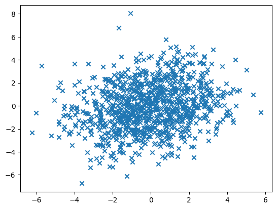

```python
# Nos données artificielles (2D)
np.random.seed(0)
data, y = gen_arti(centerx=1, centery=1, sigma=0.9, nbex=1000, data_type=0, epsilon=1.5)

plot_data(data)
```

```python
# Séparation en train/test (70% train, 30% test)
data_train, data_test, y_train, y_test = train_test_split(data, y, test_size=0.3, random_state=42)
```

```python
# MAX_DEPTH = 1

# Entraînement sur train
classifiers, alphas, epsilons, Z_values = AdaBoost_algorithm(data_train, y_train, T=100, max_depth=1)

# Prédiction sur train
y_pred_train = AdaBoost_classifier(data_train, classifiers, alphas)
train_acc = (y_pred_train == y_train.ravel()).mean() * 100
print("Accuracy sur les données train:", train_acc)

# Prédiction sur test
y_pred_test = AdaBoost_classifier(data_test, classifiers, alphas)
test_acc = (y_pred_test == y_test.ravel()).mean() * 100
print("Accuracy sur les données test:", test_acc)
```

```
Iteration 1: epsilon_t = 0.2629, alpha_t = 0.5156, Z_t = 0.8804
Iteration 2: epsilon_t = 0.3101, alpha_t = 0.3997, Z_t = 0.9251
Iteration 3: epsilon_t = 0.4384, alpha_t = 0.1238, Z_t = 0.9924
Iteration 4: epsilon_t = 0.3891, alpha_t = 0.2255, Z_t = 0.9751
Iteration 5: epsilon_t = 0.4657, alpha_t = 0.0687, Z_t = 0.9976
Iteration 6: epsilon_t = 0.4538, alpha_t = 0.0926, Z_t = 0.9957
Iteration 7: epsilon_t = 0.4235, alpha_t = 0.1543, Z_t = 0.9882
Iteration 8: epsilon_t = 0.4262, alpha_t = 0.1487, Z_t = 0.9891
Iteration 9: epsilon_t = 0.4282, alpha_t = 0.1446, Z_t = 0.9896
Iteration 10: epsilon_t = 0.4372, alpha_t = 0.1263, Z_t = 0.9921
Iteration 11: epsilon_t = 0.4406, alpha_t = 0.1194, Z_t = 0.9929
Iteration 12: epsilon_t = 0.4391, alpha_t = 0.1225, Z_t = 0.9925
Iteration 13: epsilon_t = 0.4747, alpha_t = 0.0507, Z_t = 0.9987
Iteration 14: epsilon_t = 0.4860, alpha_t = 0.0279, Z_t = 0.9996
Iteration 15: epsilon_t = 0.4864, alpha_t = 0.0272, Z_t = 0.9996
Iteration 16: epsilon_t = 0.4747, alpha_t = 0.0507, Z_t = 0.9987
Iteration 17: epsilon_t = 0.4759, alpha_t = 0.0482, Z_t = 0.9988
Iteration 18: epsilon_t = 0.4432, alpha_t = 0.1140, Z_t = 0.9935
Iteration 19: epsilon_t = 0.4803, alpha_t = 0.0395, Z_t = 0.9992
Iteration 20: epsilon_t = 0.4776, alpha_t = 0.0449, Z_t = 0.9990
Iteration 21: epsilon_t = 0.4778, alpha_t = 0.0444, Z_t = 0.9990
Iteration 22: epsilon_t = 0.4788, alpha_t = 0.0425, Z_t = 0.9991
Iteration 23: epsilon_t = 0.4794, alpha_t = 0.0413, Z_t = 0.9991
Iteration 24: epsilon_t = 0.4898, alpha_t = 0.0205, Z_t = 0.9998
Iteration 25: epsilon_t = 0.4894, alpha_t = 0.0212, Z_t = 0.9998
Iteration 26: epsilon_t = 0.4800, alpha_t = 0.0400, Z_t = 0.9992
Iteration 27: epsilon_t = 0.4808, alpha_t = 0.0384, Z_t = 0.9993
Iteration 28: epsilon_t = 0.4883, alpha_t = 0.0233, Z_t = 0.9997
Iteration 29: epsilon_t = 0.4476, alpha_t = 0.1051, Z_t = 0.9945
Iteration 30: epsilon_t = 0.4599, alpha_t = 0.0804, Z_t = 0.9968
Iteration 31: epsilon_t = 0.4684, alpha_t = 0.0633, Z_t = 0.9980
Iteration 32: epsilon_t = 0.4828, alpha_t = 0.0344, Z_t = 0.9994
Iteration 33: epsilon_t = 0.4913, alpha_t = 0.0174, Z_t = 0.9998
Iteration 34: epsilon_t = 0.4915, alpha_t = 0.0171, Z_t = 0.9999
Iteration 35: epsilon_t = 0.4916, alpha_t = 0.0168, Z_t = 0.9999
Iteration 36: epsilon_t = 0.4916, alpha_t = 0.0168, Z_t = 0.9999
Iteration 37: epsilon_t = 0.4838, alpha_t = 0.0325, Z_t = 0.9995
Iteration 38: epsilon_t = 0.4842, alpha_t = 0.0317, Z_t = 0.9995
Iteration 39: epsilon_t = 0.4921, alpha_t = 0.0158, Z_t = 0.9999
Iteration 40: epsilon_t = 0.4919, alpha_t = 0.0163, Z_t = 0.9999
```

[output cut: 47 more lines]

```
Iteration 88: epsilon_t = 0.4909, alpha_t = 0.0182, Z_t = 0.9998
Iteration 89: epsilon_t = 0.4906, alpha_t = 0.0187, Z_t = 0.9998
Iteration 90: epsilon_t = 0.4908, alpha_t = 0.0184, Z_t = 0.9998
Iteration 91: epsilon_t = 0.4910, alpha_t = 0.0181, Z_t = 0.9998
Iteration 92: epsilon_t = 0.4910, alpha_t = 0.0181, Z_t = 0.9998
Iteration 93: epsilon_t = 0.4911, alpha_t = 0.0178, Z_t = 0.9998
Iteration 94: epsilon_t = 0.4913, alpha_t = 0.0174, Z_t = 0.9998
Iteration 95: epsilon_t = 0.4914, alpha_t = 0.0173, Z_t = 0.9999
Iteration 96: epsilon_t = 0.4914, alpha_t = 0.0173, Z_t = 0.9999
Iteration 97: epsilon_t = 0.4914, alpha_t = 0.0172, Z_t = 0.9999
Iteration 98: epsilon_t = 0.4916, alpha_t = 0.0169, Z_t = 0.9999
Iteration 99: epsilon_t = 0.4916, alpha_t = 0.0167, Z_t = 0.9999
Iteration 100: epsilon_t = 0.4916, alpha_t = 0.0167, Z_t = 0.9999
Accuracy sur les données train: 78.0
Accuracy sur les données test: 79.0
```

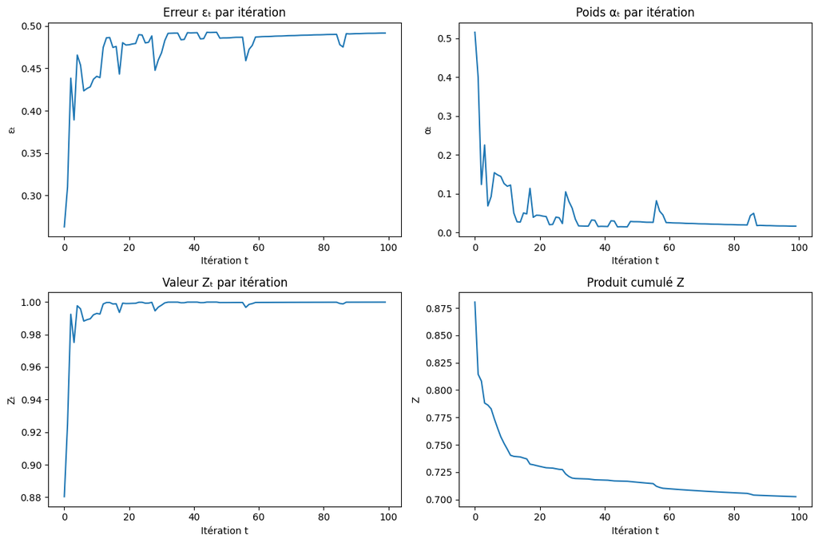

```python
Z = np.cumprod(Z_values)

plt.figure(figsize=(12, 8))

plt.subplot(2, 2, 1)
plt.plot(epsilons)
plt.title("Erreur εₜ par itération")
plt.xlabel("Itération t")
plt.ylabel("εₜ")

plt.subplot(2, 2, 2)
plt.plot(alphas)
plt.title("Poids αₜ par itération")
plt.xlabel("Itération t")
plt.ylabel("αₜ")

plt.subplot(2, 2, 3)
plt.plot(Z_values)
plt.title("Valeur Zₜ par itération")
plt.xlabel("Itération t")
plt.ylabel("Zₜ")

plt.subplot(2, 2, 4)
plt.plot(Z)
plt.title("Produit cumulé Z")
plt.xlabel("Itération t")
plt.ylabel("Z")

plt.tight_layout()
plt.show()
```

```python
# MAX_DEPTH = 5

# Entraînement sur train
classifiers, alphas, epsilons, Z_values = AdaBoost_algorithm(data_train, y_train, T=100, max_depth=5)

# Prédiction sur train
y_pred_train = AdaBoost_classifier(data_train, classifiers, alphas)
train_acc = (y_pred_train == y_train.ravel()).mean() * 100
print("Accuracy sur les données train:", train_acc)

# Prédiction sur test
y_pred_test = AdaBoost_classifier(data_test, classifiers, alphas)
test_acc = (y_pred_test == y_test.ravel()).mean() * 100
print("Accuracy sur les données test:", test_acc)
```

```
Iteration 1: epsilon_t = 0.1814, alpha_t = 0.7533, Z_t = 0.7707
Iteration 2: epsilon_t = 0.2527, alpha_t = 0.5421, Z_t = 0.8691
Iteration 3: epsilon_t = 0.2508, alpha_t = 0.5471, Z_t = 0.8670
Iteration 4: epsilon_t = 0.3464, alpha_t = 0.3174, Z_t = 0.9517
Iteration 5: epsilon_t = 0.3375, alpha_t = 0.3371, Z_t = 0.9457
Iteration 6: epsilon_t = 0.3562, alpha_t = 0.2960, Z_t = 0.9577
Iteration 7: epsilon_t = 0.4032, alpha_t = 0.1961, Z_t = 0.9811
Iteration 8: epsilon_t = 0.4356, alpha_t = 0.1296, Z_t = 0.9917
Iteration 9: epsilon_t = 0.4340, alpha_t = 0.1328, Z_t = 0.9912
Iteration 10: epsilon_t = 0.3934, alpha_t = 0.2166, Z_t = 0.9770
Iteration 11: epsilon_t = 0.4145, alpha_t = 0.1727, Z_t = 0.9853
Iteration 12: epsilon_t = 0.4064, alpha_t = 0.1894, Z_t = 0.9823
Iteration 13: epsilon_t = 0.4017, alpha_t = 0.1991, Z_t = 0.9805
Iteration 14: epsilon_t = 0.3910, alpha_t = 0.2216, Z_t = 0.9759
Iteration 15: epsilon_t = 0.4113, alpha_t = 0.1793, Z_t = 0.9841
Iteration 16: epsilon_t = 0.4345, alpha_t = 0.1318, Z_t = 0.9914
Iteration 17: epsilon_t = 0.3966, alpha_t = 0.2099, Z_t = 0.9784
Iteration 18: epsilon_t = 0.4143, alpha_t = 0.1731, Z_t = 0.9852
Iteration 19: epsilon_t = 0.4017, alpha_t = 0.1992, Z_t = 0.9805
Iteration 20: epsilon_t = 0.3491, alpha_t = 0.3115, Z_t = 0.9534
Iteration 21: epsilon_t = 0.3690, alpha_t = 0.2682, Z_t = 0.9651
Iteration 22: epsilon_t = 0.3542, alpha_t = 0.3003, Z_t = 0.9566
Iteration 23: epsilon_t = 0.3436, alpha_t = 0.3236, Z_t = 0.9498
Iteration 24: epsilon_t = 0.3559, alpha_t = 0.2967, Z_t = 0.9575
Iteration 25: epsilon_t = 0.3793, alpha_t = 0.2463, Z_t = 0.9704
Iteration 26: epsilon_t = 0.3810, alpha_t = 0.2427, Z_t = 0.9712
Iteration 27: epsilon_t = 0.3580, alpha_t = 0.2920, Z_t = 0.9588
Iteration 28: epsilon_t = 0.3412, alpha_t = 0.3290, Z_t = 0.9482
Iteration 29: epsilon_t = 0.3520, alpha_t = 0.3051, Z_t = 0.9552
Iteration 30: epsilon_t = 0.3975, alpha_t = 0.2079, Z_t = 0.9788
Iteration 31: epsilon_t = 0.3548, alpha_t = 0.2989, Z_t = 0.9569
Iteration 32: epsilon_t = 0.3552, alpha_t = 0.2981, Z_t = 0.9572
Iteration 33: epsilon_t = 0.4293, alpha_t = 0.1423, Z_t = 0.9900
Iteration 34: epsilon_t = 0.4012, alpha_t = 0.2002, Z_t = 0.9803
Iteration 35: epsilon_t = 0.4086, alpha_t = 0.1848, Z_t = 0.9832
Iteration 36: epsilon_t = 0.4104, alpha_t = 0.1812, Z_t = 0.9838
Iteration 37: epsilon_t = 0.4226, alpha_t = 0.1560, Z_t = 0.9880
Iteration 38: epsilon_t = 0.4178, alpha_t = 0.1659, Z_t = 0.9864
Iteration 39: epsilon_t = 0.3876, alpha_t = 0.2286, Z_t = 0.9744
Iteration 40: epsilon_t = 0.3969, alpha_t = 0.2092, Z_t = 0.9785
```

[output cut: 47 more lines]

```
Iteration 88: epsilon_t = 0.4047, alpha_t = 0.1930, Z_t = 0.9817
Iteration 89: epsilon_t = 0.4139, alpha_t = 0.1739, Z_t = 0.9851
Iteration 90: epsilon_t = 0.4257, alpha_t = 0.1497, Z_t = 0.9889
Iteration 91: epsilon_t = 0.4369, alpha_t = 0.1270, Z_t = 0.9920
Iteration 92: epsilon_t = 0.4195, alpha_t = 0.1624, Z_t = 0.9870
Iteration 93: epsilon_t = 0.4092, alpha_t = 0.1836, Z_t = 0.9834
Iteration 94: epsilon_t = 0.3909, alpha_t = 0.2217, Z_t = 0.9759
Iteration 95: epsilon_t = 0.4227, alpha_t = 0.1558, Z_t = 0.9880
Iteration 96: epsilon_t = 0.4257, alpha_t = 0.1497, Z_t = 0.9889
Iteration 97: epsilon_t = 0.4297, alpha_t = 0.1416, Z_t = 0.9901
Iteration 98: epsilon_t = 0.4221, alpha_t = 0.1571, Z_t = 0.9878
Iteration 99: epsilon_t = 0.4179, alpha_t = 0.1657, Z_t = 0.9864
Iteration 100: epsilon_t = 0.4343, alpha_t = 0.1321, Z_t = 0.9913
Accuracy sur les données train: 100.0
Accuracy sur les données test: 76.33333333333333
```

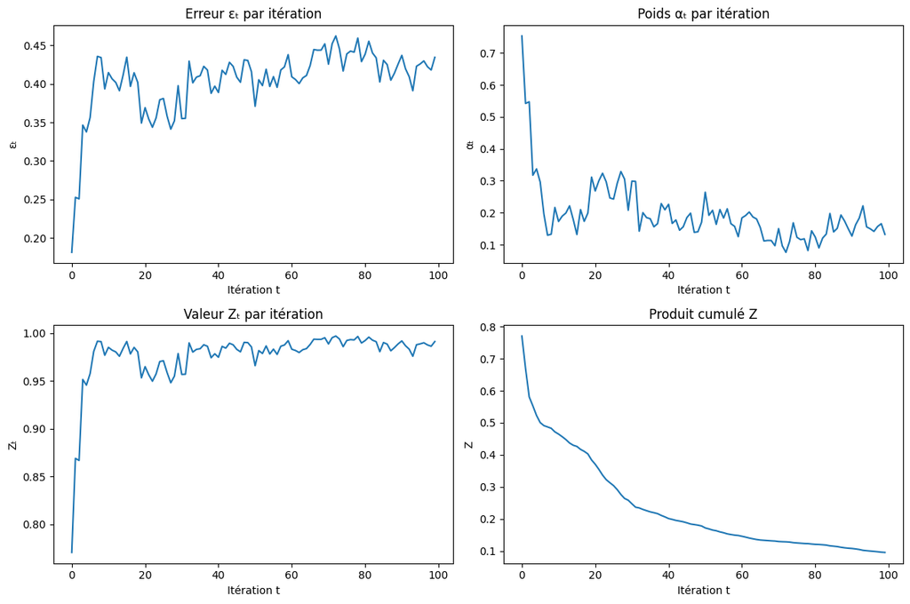

```python
Z = np.cumprod(Z_values)

plt.figure(figsize=(12, 8))

plt.subplot(2, 2, 1)
plt.plot(epsilons)
plt.title("Erreur εₜ par itération")
plt.xlabel("Itération t")
plt.ylabel("εₜ")

plt.subplot(2, 2, 2)
plt.plot(alphas)
plt.title("Poids αₜ par itération")
plt.xlabel("Itération t")
plt.ylabel("αₜ")

plt.subplot(2, 2, 3)
plt.plot(Z_values)
plt.title("Valeur Zₜ par itération")
plt.xlabel("Itération t")
plt.ylabel("Zₜ")

plt.subplot(2, 2, 4)
plt.plot(Z)
plt.title("Produit cumulé Z")
plt.xlabel("Itération t")
plt.ylabel("Z")

plt.tight_layout()
plt.show()
```

En ce qui concerne l’erreur $\epsilon_t$, on observe qu'elle tend à rester proche de 0.5 au fil des itérations. Cela signifie que les nouveaux classifieurs n’apportent plus d’amélioration significative, et que leurs performances sont proches du hasard (erreur de 50%).  
Pour les poids $\alpha_t$, on voit une décroissance au cours des itérations : les premiers classifieurs ont des poids plus élevés car ils sont efficaces sur les données encore équilibrées uniformément. Plus on avance dans les itérations, plus les erreurs deviennent spécifiques, et les nouveaux arbres ont donc un poids plus faible car ils corrigent des cas plus isolés.  
Concernant le produit cumulé des normalisations $Z$, on observe aussi une diminution au fil des itérations. Cela signifie que le modèle global s'améliore : plus le modèle est bon, plus la somme pondérée des erreurs exponentielles diminue, ce qui entraîne une baisse de $Z$.

Conclusion :  
Le bagging vise à réduire la variance du modèle en moyennant les prédictions de plusieurs arbres indépendants, tandis que le boosting cherche à réduire le biais en se concentrant sur les erreurs des itérations précédentes. Ainsi, le bagging est généralement plus robuste au surapprentissage, même avec des arbres profonds, grâce à l’effet de moyenne. Le boosting, lui, est plus sensible au surapprentissage si les arbres sont trop complexes ou trop nombreux, car il s'ajuste très finement aux données d'entraînement.